# beagle_quenching_test_20180607

### quenching

- Since we have a high concentration of Phycocyanin and Chlorophyll a as well as high cell counts we should expect that undiluted samples will show quenching or interference so the the values should increase with dilution.
- The data are plotted two ways.
  - First we plot the raw data against the dilution factor (log2 scale)
  - Then the raw data are corrected for dilution by multiplying by the dilution factor and reploted.
  - Presented are the data for the frozen samples for all six Beagle outputs (Chla, PC, RFU1_high, RFU1_lo, RFU2_high, and RFU2_lo)

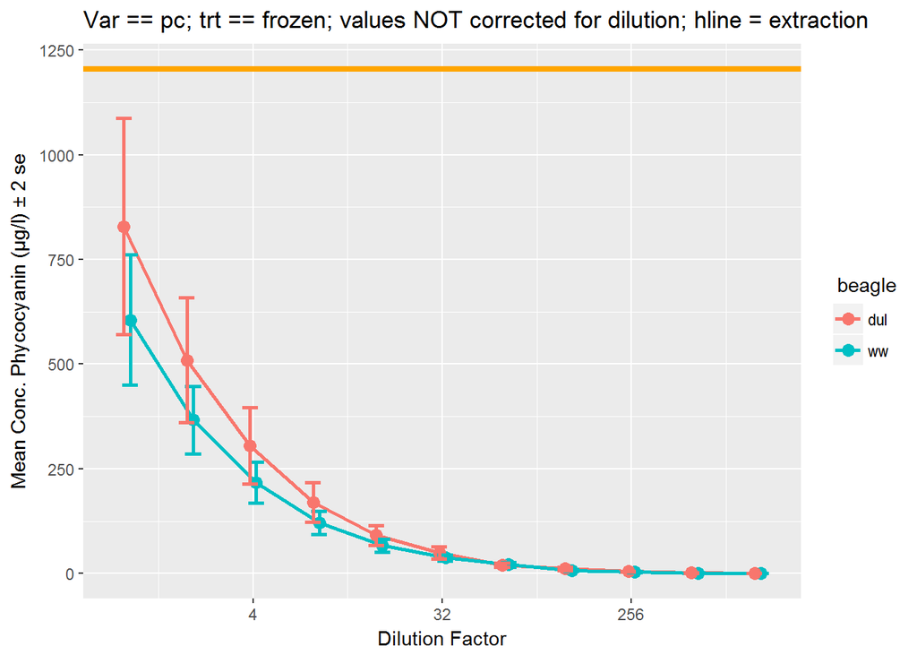

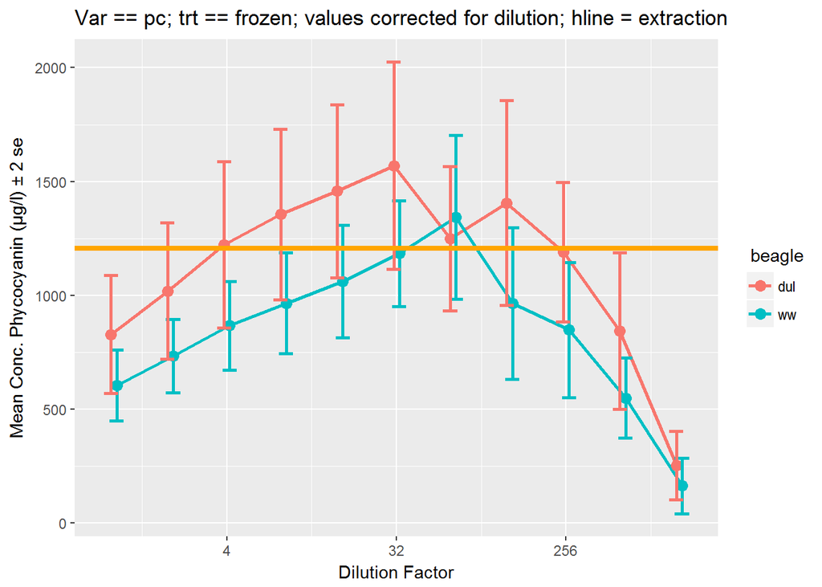

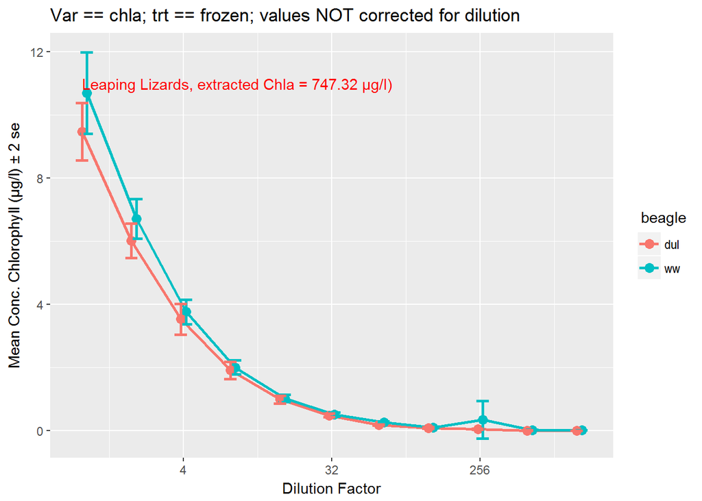

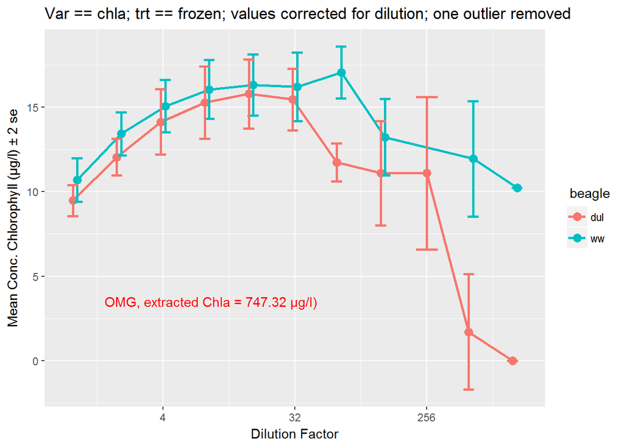

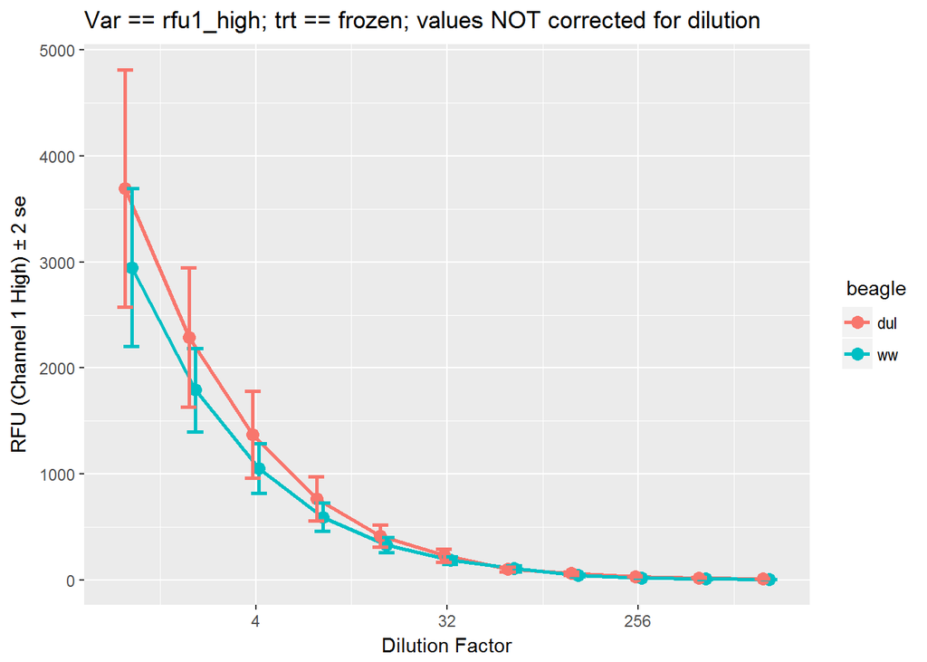

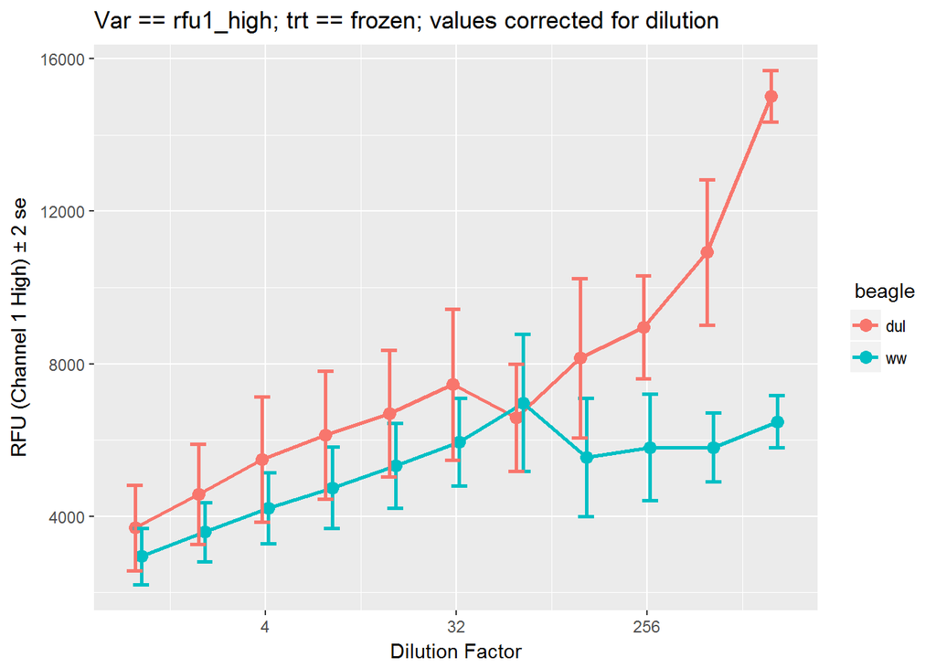

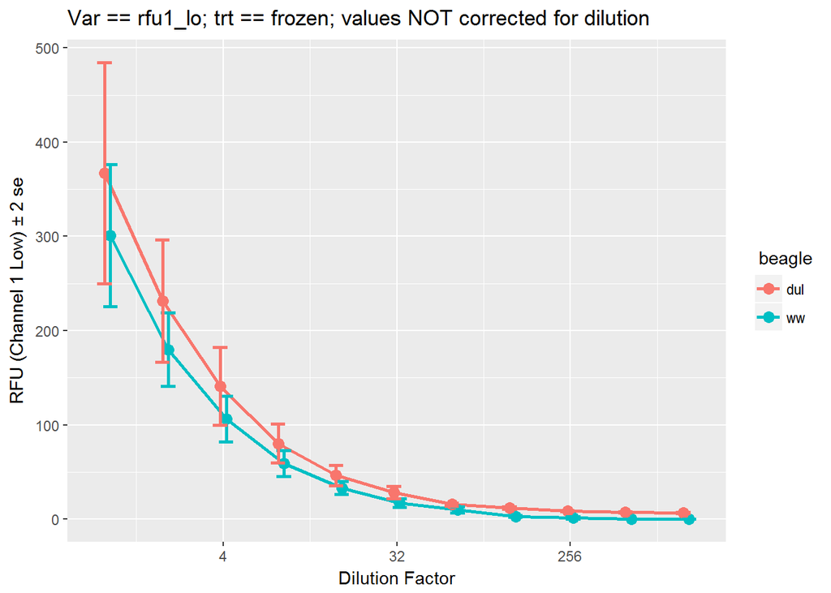

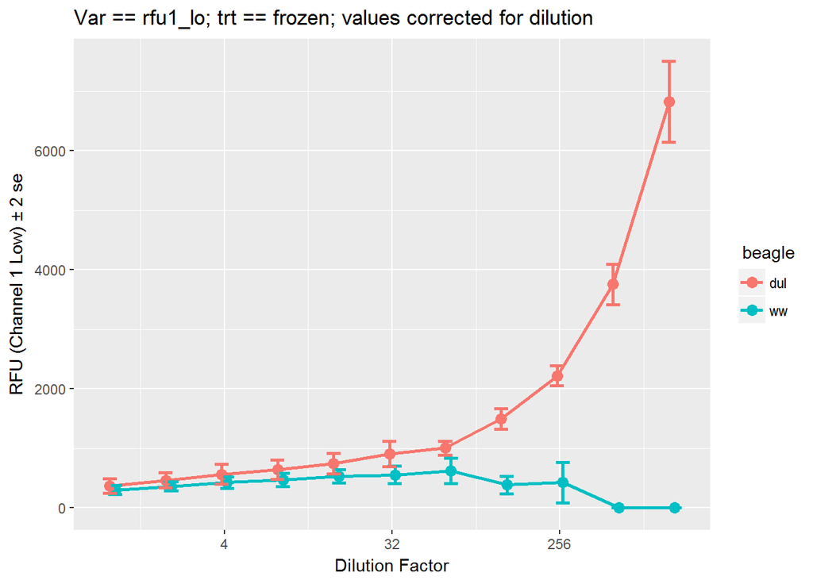

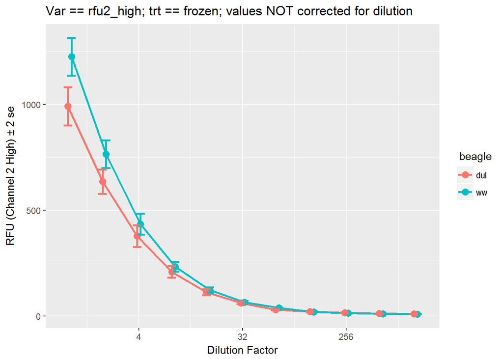

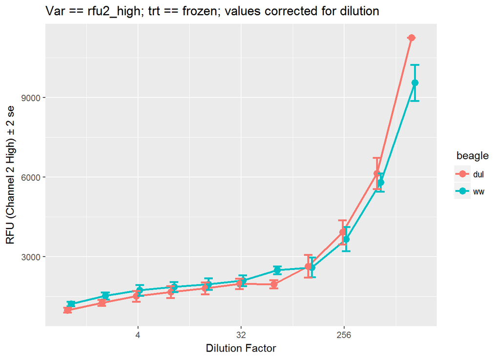

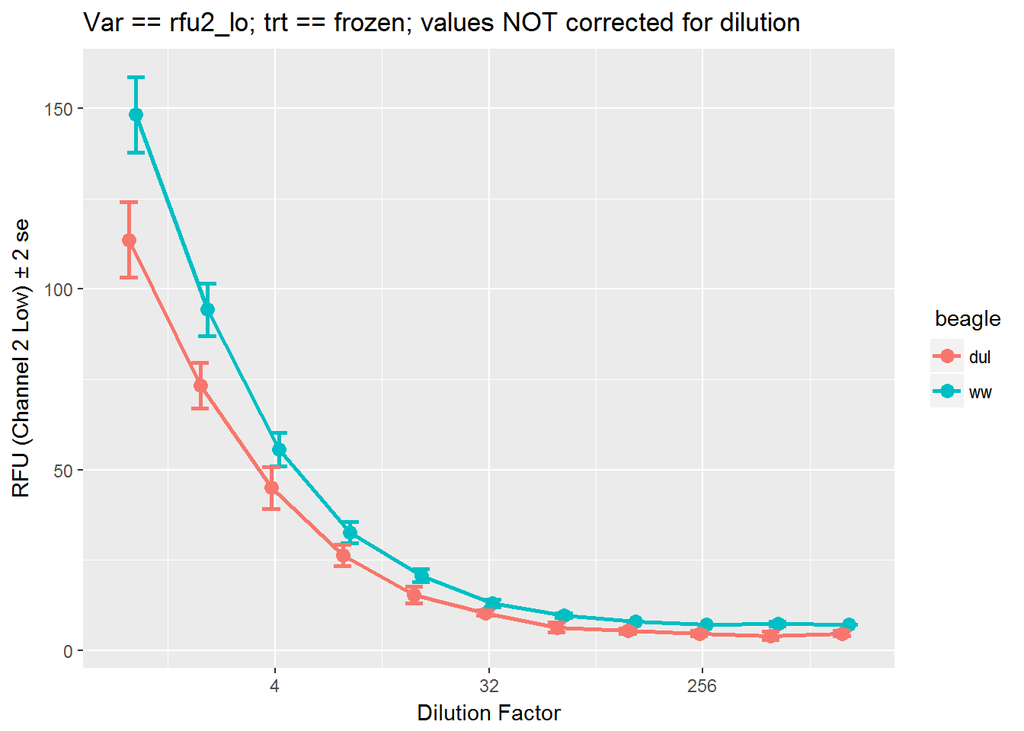

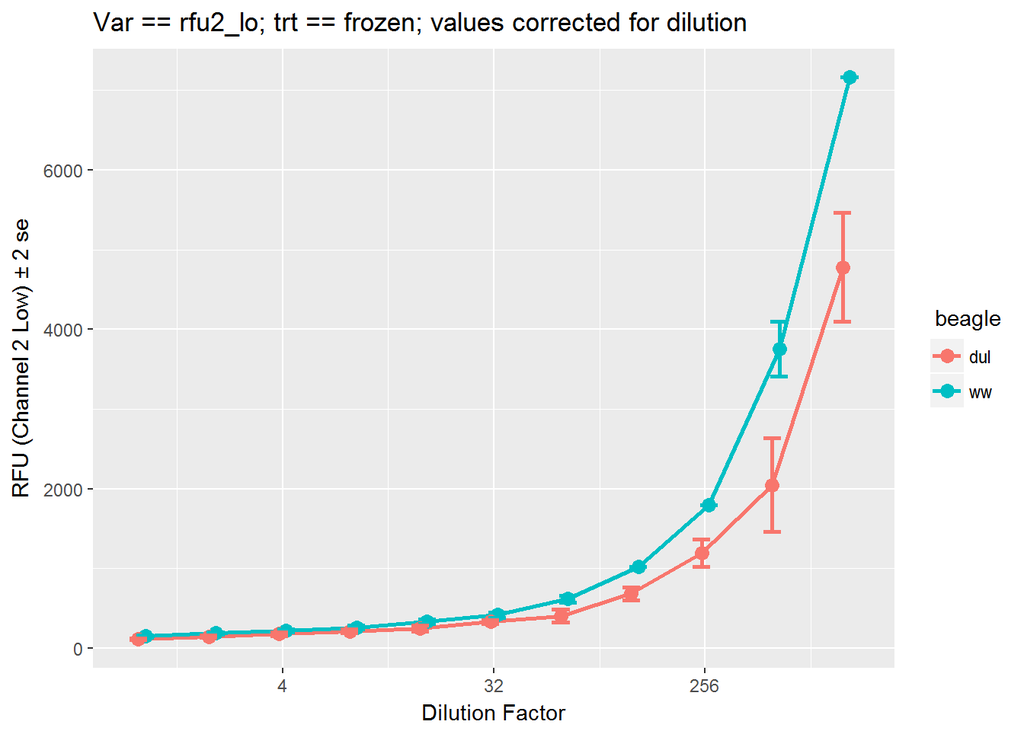

### Fresh vs. Frozen vs Dark Adapted

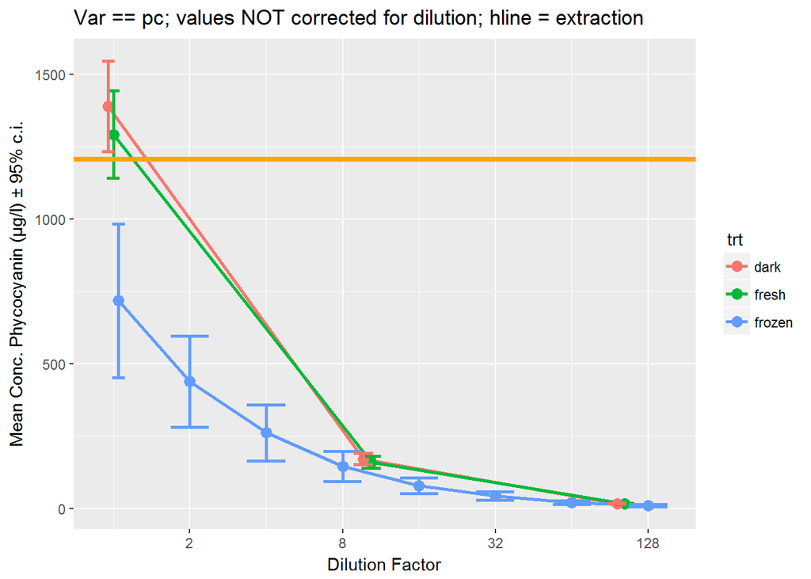

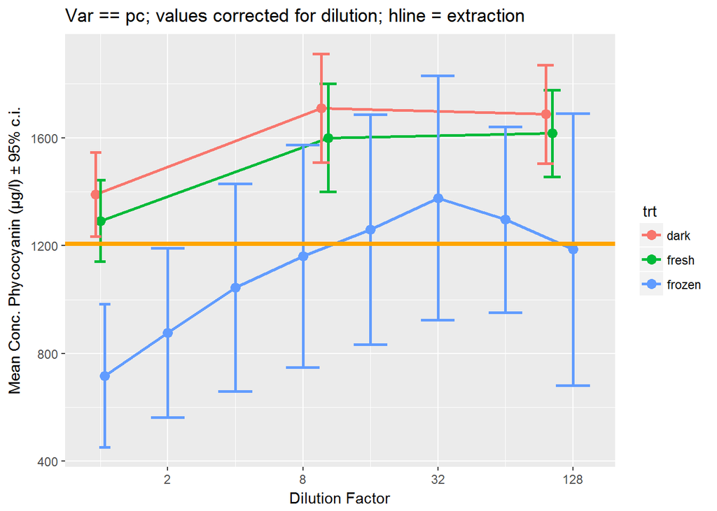

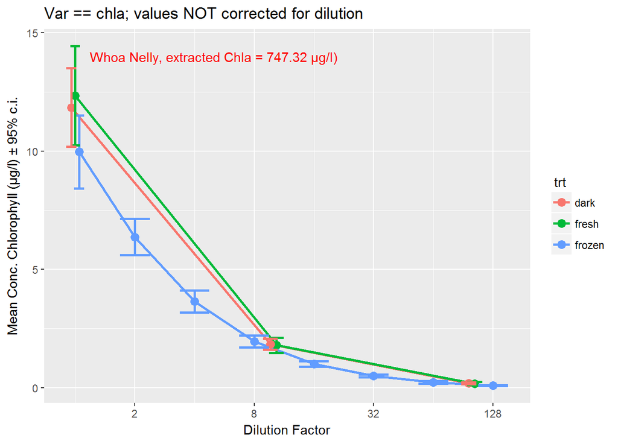

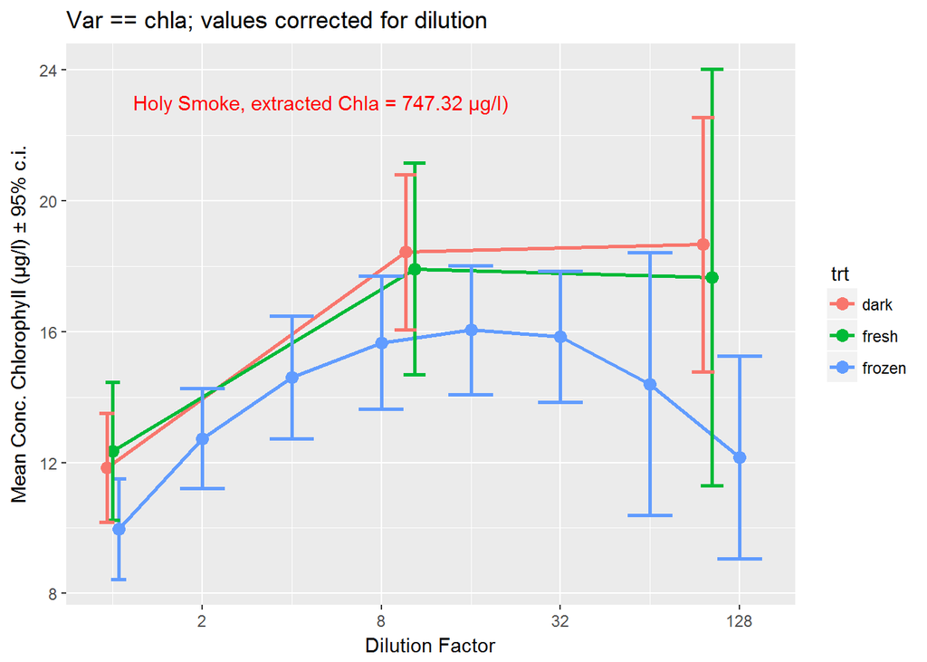

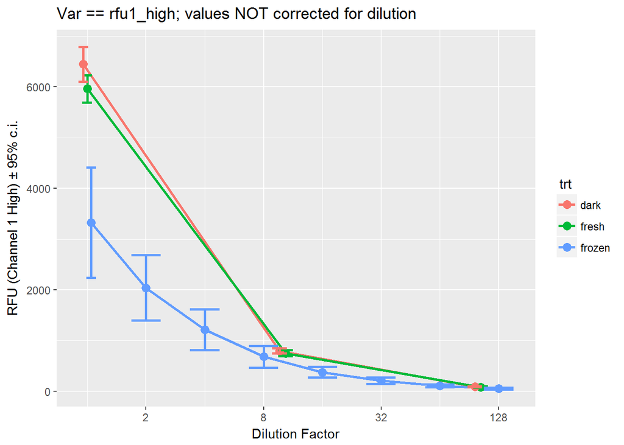

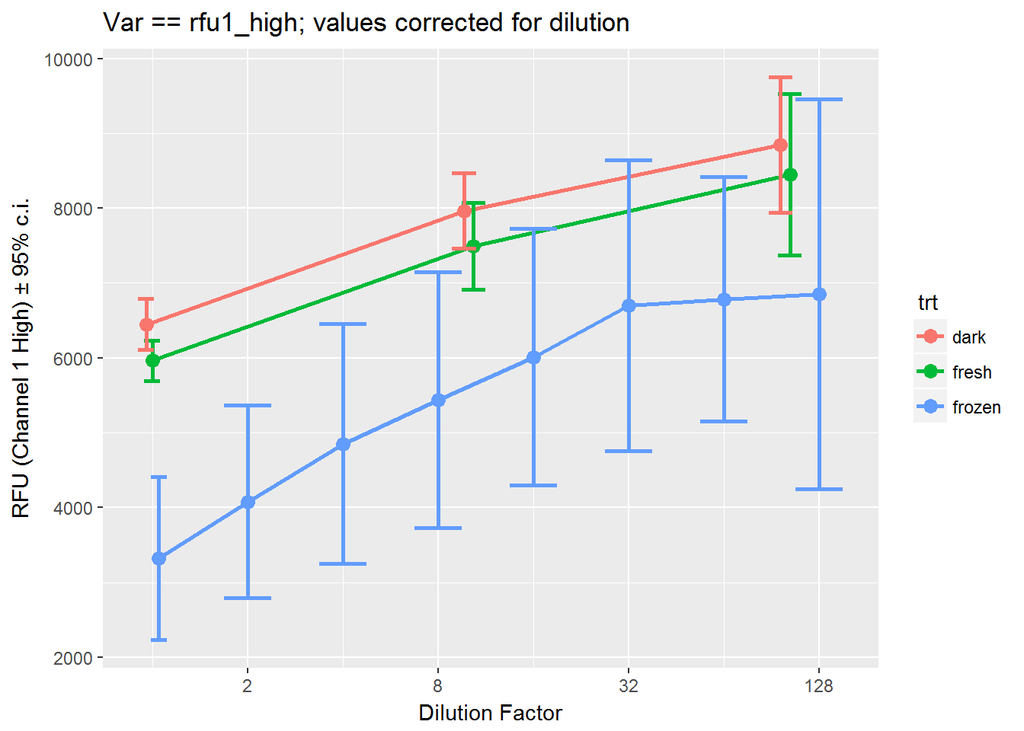

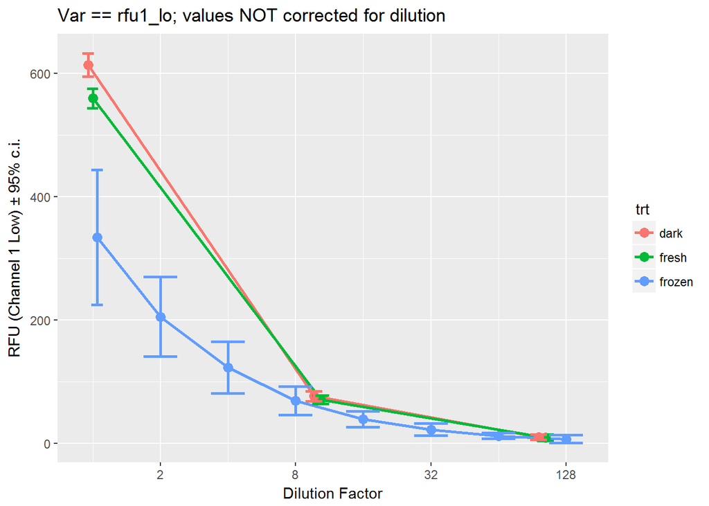

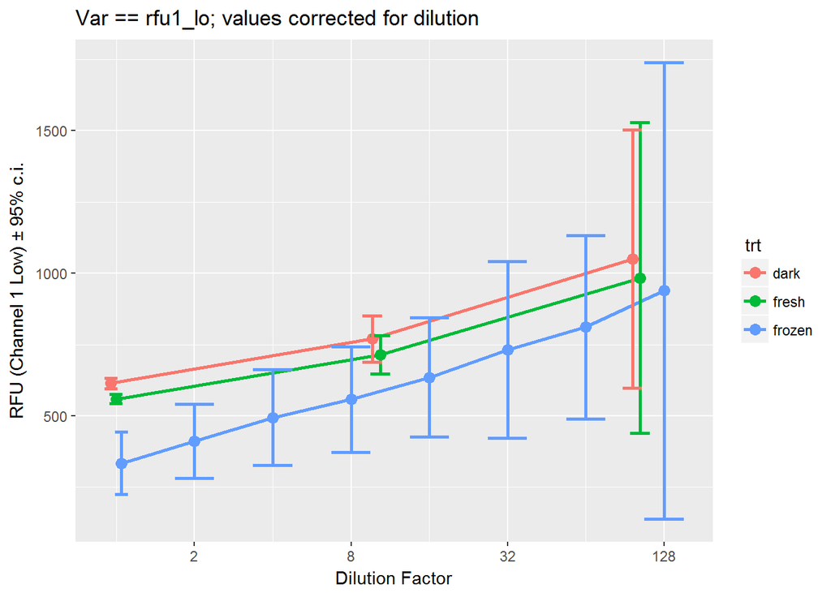

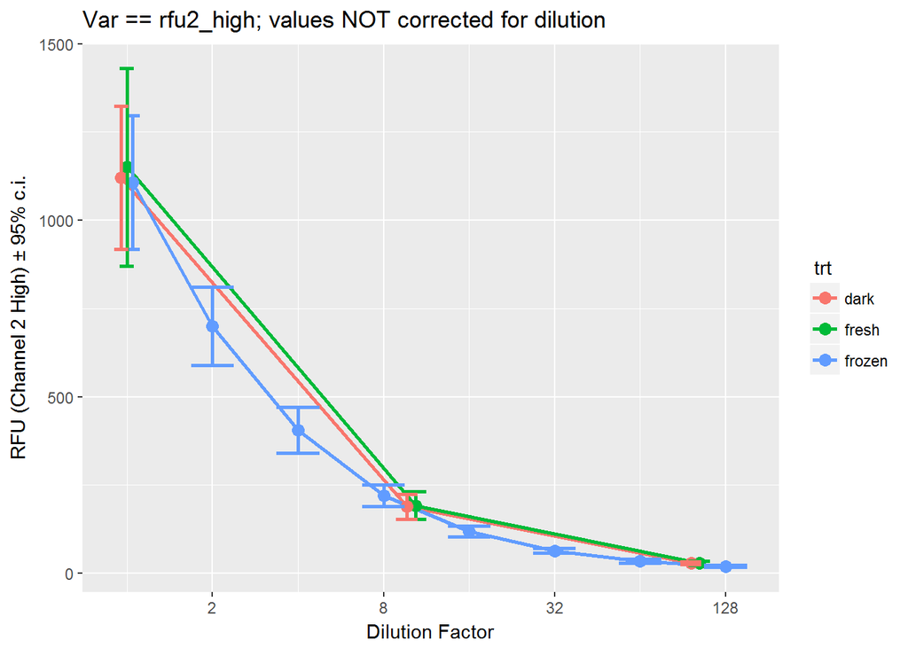

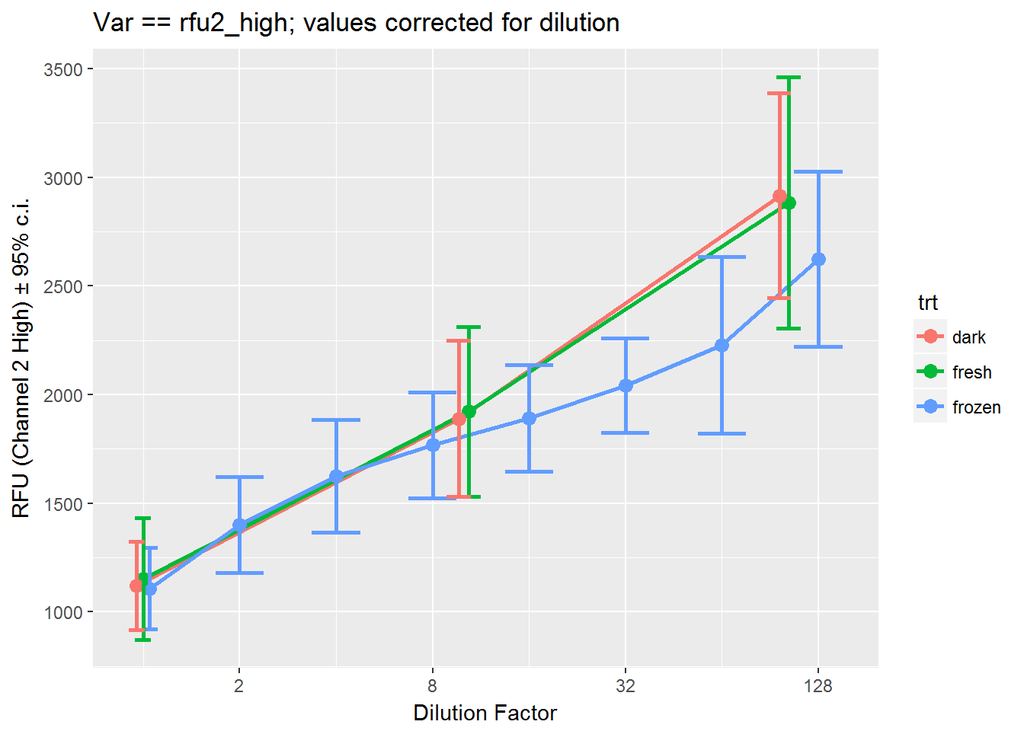

[figure not shown]

[figure not shown]

### Light adapted vs. dark adapted